# Final Report: Regression Problem

Regression Problem  
Data Science 3 with R (STAT 301-3)

Author

Reed Malcolm

Published

June 4, 2025

**Github Repo Link**

[Reed’s Regression Problem GitHub Repo](https://github.com/stat301-3-2025-spring/reg-pred-prob-malcor21.git)

## Introduction

Price prediction using machine learning has become increasingly prominent in the rental space due to the prevalence of rate-recommendation platforms like RealPage.[^1] Machine learning is particularly amenable to rental properties on the basis of their wealth of physical and administrative qualities to guide prediction. A timeshare service like Airbnb could utilize such methods, for example, to advise hosts’ pricing decisions based on listing characteristics.

<sup>1</sup> Vegari, A. and Anderson, C (2025), [RealPage Opens New Front in Algorithmic Pricing Challenges with Suit Challenging Berkeley Ordinance](https://www.pbwt.com/antitrust-update-blog/realpage-opens-new-front-in-algorithmic-pricing-challenges-with-suit-challenging-berkeley-ordinance)

<sup>2</sup> Arend Kuyper (2025), [Regression (Spring 2025): Airbnb prices](https://www.kaggle.com/competitions/regression-spring-2025-airbnb-prices/overview)

This regression exercise seeks to construct that type of model, using machine learning workflows to predict Airbnb rental prices based on physical and demographic qualities. As part of a coursewide data science competition, this prediction problem adheres to the model building and submission guidelines listed on the corresponding Kaggle page. Airbnb listing data for the exercise was also provided on Kaggle.[^2]

The Airbnb regression prediction problem seeks to forecast price using modeling techniques covered in the Stat 301 course sequence. This repository is structured by workflow, with each pipeline constituting a wave of model submissions to the Kaggle competition. Workflows consist of all predictive modeling steps save for data cleaning: variable selection, preprocessing, model fitting and tuning, evaluation, and final fitting. A variety of model types were employed for the exercise, including generalized linear, random forest, boosted trees, k-nearest neighbors, and neural network workflows. Submission pipelines were constructed until the A grade threshold, a mean absolute error (MAE) of 97 or less, was achieved by a generated model. This report examines two models from the project: a boosted trees workflow that exceeded the A threshold, and a random forest model to discuss robustness.

## Selected Model 1

The first selected model was `rf1_11_predict.csv`, the strongest random forest model generated during the first submission wave.

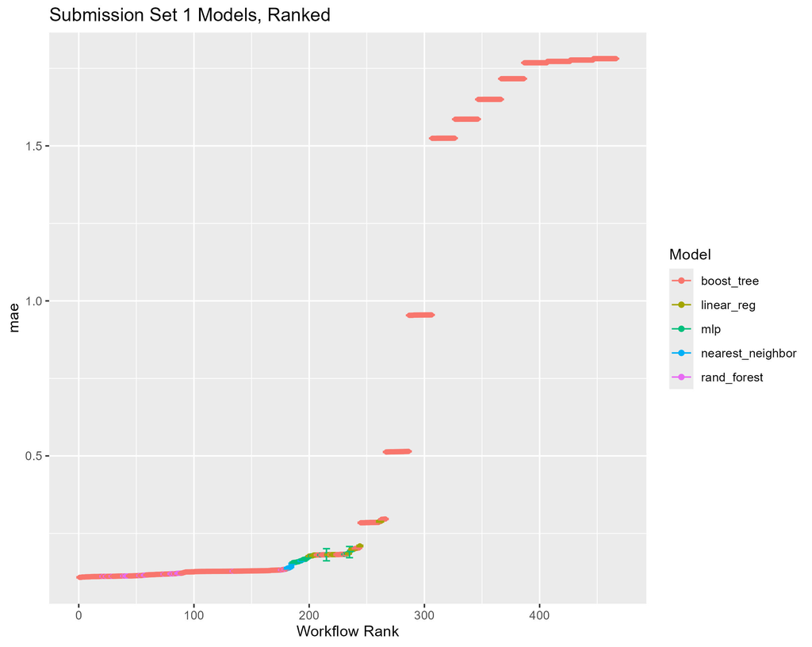

Figure 1: Submission Set 1 Models, Ranked

The first submission set took a broad approach to predicting price. After implementing the basic data cleaning steps for information extraction discussed in class—capturing common amenities, bathrooms per listing, etc.—I utilized a kitchen-sink philosophy for tuning and preprocessing. Variable selection was conducted using a minimal-processing random forest model, retrieving an arbitrary 23 variables for use in prediction. Preprocessing objects were generated for the five model types mentioned above utilizing only the required steps, and parameter values were mostly assigned to the default tuning ranges. The best models of each workflow type were advanced to the public Kaggle leaderboard for evaluation; the submitted models performed in the same relative order as their training results.

Table 1: Submission 1 Optimal Model Results

| Model_Type | Optimal_Model_Name | Public_MAE |
| --- | --- | --- |
| Boosted trees | bt1_096_predict.csv | 104.55 |
| Random forest | rf1_11_predict.csv | 105.55 |
| K-nearest neighbors | knn1_6_predict.csv | 117.97 |
| Neural network | mlp1_2_predict.csv | 137.25 |
| Generalized linear model | lasso1_1_predict.csv | 149.39 |

As shown in Table 1 above, the optimal boosted trees model proved the strongest of the first wave submissions. Further boosted trees tuning was therefore pursued in the later pipelines. However, the best random forest model finished not far behind the boosted trees. I have selected `rf1_11_predict.csv`, the best-performing non-boosted trees model tested during the exercise, as a benchmark for private leaderboard evaluation.

While the boosted trees workflow underwent extensive tuning during the subsequent two submission pipelines, the first wave’s optimal random forest model performed respectably with little to no bespoke adjustments. I am therefore interested to compare `rf1_11_predict.csv`’s private leaderboard power to that of the second selected model, which was likely overfitted to the public leaderboard on account of its extensive parameter tuning. Even if the first wave’s random forest model does not strictly outperform its boosted trees counterpart, a low relative MAE could demonstrate that the former is more generalizable to foreign Airbnb data and thus worth exploring further in the future.

## Selected Model 2

The second selected model, `bt1_07_all_predict.csv`, crossed the A grade threshold with a MAE of 96.7 on the public leaderboard. It was the best-performing boosted trees workflow from the third submission wave as well as overall.

In line with the results of the first pass, the second submission wave focused on fine-tuning the boosted trees workflow. The second submission abandoned the variable selection step (as per our discussions in class), increased the number of included amenity indicators, and added predictors extracting further text information. I also transitioned to using the `lightgbm` engine for boosted trees tuning and allowed for variation in the workflow’s tree depth and minimum loss reduction. Overall, the second submission’s optimal boosted trees model demonstrated a modest improvement to an MAE of 99.18 on the public Kaggle leaderboard.

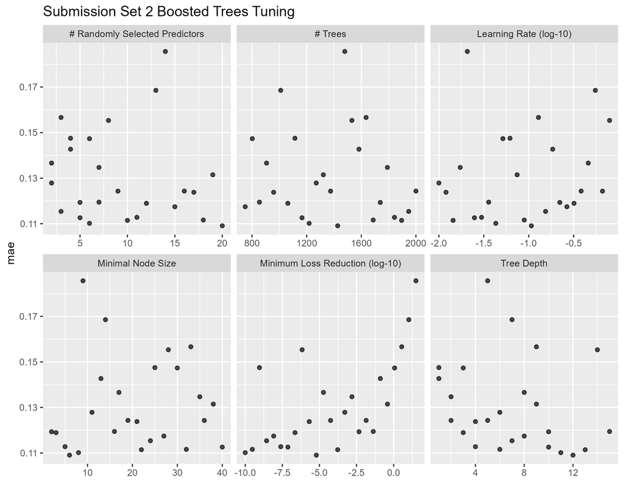

Figure 2: Submission Set 2 Boosted Trees Tuning

## AI Statement

Generative AI resources (Chat GPT-4o and perplexity.ai) to generate helper code during the project’s data cleaning process. Specifically, I used Generative AI to produce complex regular expressions and generate functions for cleaning amenities data.